# Supervised Learning Project

## Part A

Medical research university X is undergoing a deep research on patients with certain conditions. University has an internal AI team. Due to confidentiality the patient’s details and the conditions are masked by the client by providing different datasets to the AI team for developing a AIML model which can predict the condition of the patient depending on the received test results.

**Importing modules for project**

```python
import numpy as np
import pandas as pd
import seaborn as sns
import matplotlib.pyplot as plt
from sklearn.preprocessing import LabelEncoder
from scipy.stats import zscore
from sklearn.model_selection import train_test_split
from sklearn.neighbors import KNeighborsClassifier
from sklearn.linear_model import LogisticRegression
from sklearn.naive_bayes import GaussianNB
from sklearn.svm import SVC
from sklearn.metrics import accuracy_score, confusion_matrix
from sklearn.metrics import classification_report
from sklearn import model_selection
from imblearn.over_sampling import RandomOverSampler
from imblearn.over_sampling import SMOTENC
from imblearn.over_sampling import SMOTE
import warnings
warnings.filterwarnings("ignore")
```

**Read all the 3 CSV files as DataFrame and store them into 3 separate variables**

```python
normal= pd.read_csv("normal.csv")
typeh= pd.read_csv("Type_H.csv")
types= pd.read_csv("Type_S.csv")
```

**Print Shape and columns of all the 3 DataFrames**

```python
normal.shape
```

```
(100, 7)
```

This Dataframe has 7 columns and 100 rows.

```python
normal.columns
```

```
Index(['P_incidence', 'P_tilt', 'L_angle', 'S_slope', 'P_radius', 'S_Degree',
       'Class'],
      dtype='object')
```

```python
typeh.shape
```

```
(60, 7)
```

This Dataframe has 7 columns and 60 rows.

```python
typeh.columns
```

```
Index(['P_incidence', 'P_tilt', 'L_angle', 'S_slope', 'P_radius', 'S_Degree',
       'Class'],
      dtype='object')
```

```python
types.shape
```

```
(150, 7)
```

This Dataframe has 7 columns and 150 rows.

```python
typeh.columns
```

```
Index(['P_incidence', 'P_tilt', 'L_angle', 'S_slope', 'P_radius', 'S_Degree',
       'Class'],
      dtype='object')
```

```python
print(normal.head(),'\n')
print(typeh.head(),'\n')
print(types.head(),'\n')
```

```
   P_incidence     P_tilt    L_angle    S_slope    P_radius  S_Degree   Class
0    38.505273  16.964297  35.112814  21.540976  127.632875  7.986683  Normal
1    54.920858  18.968430  51.601455  35.952428  125.846646  2.001642  Normal
2    44.362490   8.945435  46.902096  35.417055  129.220682  4.994195  Normal
3    48.318931  17.452121  48.000000  30.866809  128.980308 -0.910941  Normal
4    45.701789  10.659859  42.577846  35.041929  130.178314 -3.388910  Normal

   P_incidence     P_tilt    L_angle    S_slope    P_radius   S_Degree   Class
0    63.027817  22.552586  39.609117  40.475232   98.672917  -0.254400  Type_H
1    39.056951  10.060991  25.015378  28.995960  114.405425   4.564259  Type_H
2    68.832021  22.218482  50.092194  46.613539  105.985135  -3.530317  Type_H
3    69.297008  24.652878  44.311238  44.644130  101.868495  11.211523  Type_H
4    49.712859   9.652075  28.317406  40.060784  108.168725   7.918501  Type_H

   P_incidence     P_tilt    L_angle    S_slope    P_radius   S_Degree   Class
0    74.377678  32.053104  78.772013  42.324573  143.560690  56.125906  Type_S
1    89.680567  32.704435  83.130732  56.976132  129.955476  92.027277  Type_S
2    44.529051   9.433234  52.000000  35.095817  134.711772  29.106575  Type_S
3    77.690577  21.380645  64.429442  56.309932  114.818751  26.931841  Type_S
4    76.147212  21.936186  82.961502  54.211027  123.932010  10.431972  Type_S
```

**Compare Column names of all the 3 DataFrames and clearly write observations.**

All three dataframes have same column names.

**Print DataTypes of all the 3 DataFrames.**

```python
normal.dtypes
```

```
P_incidence    float64
P_tilt         float64
L_angle        float64
S_slope        float64
P_radius       float64
S_Degree       float64
Class           object
dtype: object
```

```python
typeh.dtypes
```

```
P_incidence    float64
P_tilt         float64
L_angle        float64
S_slope        float64
P_radius       float64
S_Degree       float64
Class           object
dtype: object
```

```python
types.dtypes
```

```
P_incidence    float64
P_tilt         float64
L_angle        float64
S_slope        float64
P_radius       float64
S_Degree       float64
Class           object
dtype: object
```

columns P_incidence, P_tilt, L_angle, S_slope, P_radius, S_Degree have datatype flot and Class is an object.

**Observe and share variation in ‘Class’ feature of all the 3 DaraFrames**

```python
print(normal['Class'].value_counts(),'\n')
print(typeh['Class'].value_counts(),'\n')
print(types['Class'].value_counts(),'\n')
```

```
Normal    73
Nrmal     27
Name: Class, dtype: int64

Type_H    37
type_h    23
Name: Class, dtype: int64

Type_S    133
tp_s       17
Name: Class, dtype: int64
```

All the three dataframes have 3 different class features normal,type_H,type_S repectively. tp_s and Type_S, Normal and Nrmal,Type_H and type_h represents same class.

**Unify all the variations in ‘Class’ feature for all the 3 DataFrames.**

```python
types.loc[types['Class']=='tp_s','Class']='Type_S'
normal.loc[normal['Class']=='Nrmal','Class']='Normal'
typeh.loc[typeh['Class']=='type_h','Class']='Type_H'
```

```python
print(normal['Class'].value_counts(),'\n')
print(typeh['Class'].value_counts(),'\n')
print(types['Class'].value_counts(),'\n')
```

```
Normal    100
Name: Class, dtype: int64

Type_H    60
Name: Class, dtype: int64

Type_S    150
Name: Class, dtype: int64
```

```python
print(normal['Class'].nunique())
print(typeh['Class'].nunique())
print(types['Class'].nunique())
```

```
1
1
1
```

**Combine all the 3 DataFrames to form a single DataFrame**

```python
df=normal.append([typeh,types])
```

```python
df.reset_index(inplace=True)
df=df.drop(['index'], axis = 1)
```

```python
df
```

|  | P_incidence | P_tilt | L_angle | S_slope | P_radius | S_Degree | Class |
| --- | --- | --- | --- | --- | --- | --- | --- |
| 0 | 38.505273 | 16.964297 | 35.112814 | 21.540976 | 127.632875 | 7.986683 | Normal |
| 1 | 54.920858 | 18.968430 | 51.601455 | 35.952428 | 125.846646 | 2.001642 | Normal |
| 2 | 44.362490 | 8.945435 | 46.902096 | 35.417055 | 129.220682 | 4.994195 | Normal |
| 3 | 48.318931 | 17.452121 | 48.000000 | 30.866809 | 128.980308 | -0.910941 | Normal |
| 4 | 45.701789 | 10.659859 | 42.577846 | 35.041929 | 130.178314 | -3.388910 | Normal |
| ... | ... | ... | ... | ... | ... | ... | ... |
| 305 | 80.111572 | 33.942432 | 85.101608 | 46.169139 | 125.593624 | 100.292107 | Type_S |
| 306 | 95.480229 | 46.550053 | 59.000000 | 48.930176 | 96.683903 | 77.283072 | Type_S |
| 307 | 74.094731 | 18.823727 | 76.032156 | 55.271004 | 128.405731 | 73.388216 | Type_S |
| 308 | 87.679087 | 20.365613 | 93.822416 | 67.313473 | 120.944829 | 76.730629 | Type_S |
| 309 | 48.259920 | 16.417462 | 36.329137 | 31.842457 | 94.882336 | 28.343799 | Type_S |

310 rows × 7 columns

After combining dataframes we have 310 rows and 7 columns

**Print 5 random samples of this DataFrame**

```python
df.sample( n=5)
```

|  | P_incidence | P_tilt | L_angle | S_slope | P_radius | S_Degree | Class |
| --- | --- | --- | --- | --- | --- | --- | --- |
| 262 | 118.144655 | 38.449501 | 50.838520 | 79.695154 | 81.024541 | 74.043767 | Type_S |
| 297 | 58.828379 | 37.577873 | 125.742385 | 21.250506 | 135.629418 | 117.314683 | Type_S |
| 42 | 42.918041 | -5.845994 | 58.000000 | 48.764035 | 121.606859 | -3.362045 | Normal |
| 280 | 37.903910 | 4.479099 | 24.710274 | 33.424811 | 157.848799 | 33.607027 | Type_S |
| 6 | 50.913101 | 6.677000 | 30.896522 | 44.236102 | 118.151531 | -1.057986 | Normal |

**Print Feature-wise percentage of Null values**

```python
df.isnull().sum()
```

```
P_incidence    0
P_tilt         0
L_angle        0
S_slope        0
P_radius       0
S_Degree       0
Class          0
dtype: int64
```

There are no null values in this dataframe

**Check 5-point summary of the new DataFrame.**

```python
df.describe()
```

|  | P_incidence | P_tilt | L_angle | S_slope | P_radius | S_Degree |
| --- | --- | --- | --- | --- | --- | --- |
| count | 310.000000 | 310.000000 | 310.000000 | 310.000000 | 310.000000 | 310.000000 |
| mean | 60.496653 | 17.542822 | 51.930930 | 42.953831 | 117.920655 | 26.296694 |
| std | 17.236520 | 10.008330 | 18.554064 | 13.423102 | 13.317377 | 37.559027 |
| min | 26.147921 | -6.554948 | 14.000000 | 13.366931 | 70.082575 | -11.058179 |
| 25% | 46.430294 | 10.667069 | 37.000000 | 33.347122 | 110.709196 | 1.603727 |
| 50% | 58.691038 | 16.357689 | 49.562398 | 42.404912 | 118.268178 | 11.767934 |
| 75% | 72.877696 | 22.120395 | 63.000000 | 52.695888 | 125.467674 | 41.287352 |
| max | 129.834041 | 49.431864 | 125.742385 | 121.429566 | 163.071041 | 418.543082 |

**P_incidence** P_incidence has nearly equal mean and median.

75% of data is less than 72

maximum value is 129

disturbution of data can be assumed normal

**P_tilt** P_tilt has nearly equal mean and median.

75% of data is less than 22

negitive values are present

maximum value is 49

disturbution of data can be assumed normal, data can have right skewness.

**L_angle** L_angle has nearly equal mean and median.

75% of data is less than 63

maximum value is 125

disturbution of data can be assumed normal

can have outliers because of the maximum value

**S_slope** S_slope has nearly equal mean and median.

75% of data is less than 52

maximum value is 121

disturbution of data can be assumed normal

can have outliers because of the maximum value

**P_radius** P_radius has nearly equal mean and median.

disturbution of data can be assumed normal

**S_degree** mean is greater than median.

there can be right skewness

75% of data is less than 41

maximum value is 418

outliers are present here.

**Visualize a heatmap to understand correlation between all features**

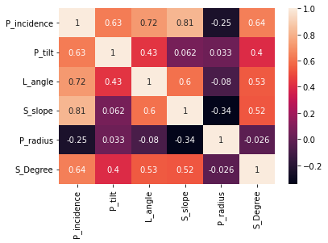

```python
sns.heatmap(df.corr(),annot=True)
```

there is high correlation between P_incidence and S_slope. P_radius is negitively correlated with L_angle,S-slope and P_incidence.

**Share insights on correlation**

A. Features having stronger correlation with correlation value.

B. Features having weaker correlation with correlation value.

```python
df.corr()
```

|  | P_incidence | P_tilt | L_angle | S_slope | P_radius | S_Degree |
| --- | --- | --- | --- | --- | --- | --- |
| P_incidence | 1.000000 | 0.629199 | 0.717282 | 0.814960 | -0.247467 | 0.638743 |
| P_tilt | 0.629199 | 1.000000 | 0.432764 | 0.062345 | 0.032668 | 0.397862 |
| L_angle | 0.717282 | 0.432764 | 1.000000 | 0.598387 | -0.080344 | 0.533667 |
| S_slope | 0.814960 | 0.062345 | 0.598387 | 1.000000 | -0.342128 | 0.523557 |
| P_radius | -0.247467 | 0.032668 | -0.080344 | -0.342128 | 1.000000 | -0.026065 |
| S_Degree | 0.638743 | 0.397862 | 0.533667 | 0.523557 | -0.026065 | 1.000000 |

P_incidence is highly correlated with s_slope with value of 0.81.

P_radius has negitive correlation with S_slope with value of -0.34.

**Visualize a pairplot with 3 classes distinguished by colors and share insights.**

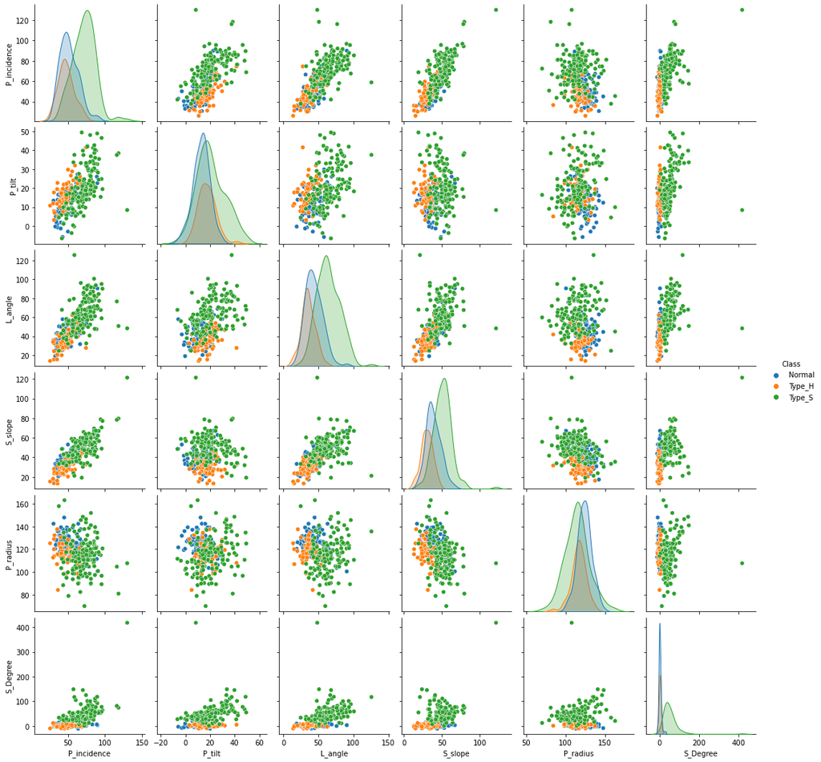

```python
sns.pairplot(df, hue="Class")
```

we can see that distrubtion of class variable is not same along the diagonal.

we can see that type_s has more rows than other two classes

**Visualize a jointplot for ‘P_incidence’ and ‘S_slope’ and share insights**

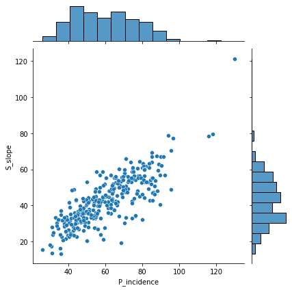

```python
sns.jointplot(x = "P_incidence", y = "S_slope", kind = "scatter", data = df)
plt.show()
```

There is linear relationship between ‘P_incidence’ and ‘S_slope’. there are possible outliers.

**Visualize a boxplot to check distribution of the features and share insight**

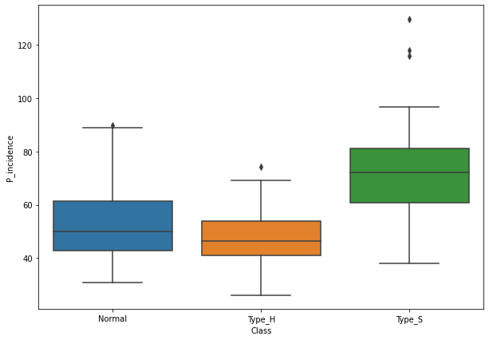

```python
plt.figure(figsize=(10,7))
sns.boxplot(x='Class', y='P_incidence', data= df)
plt.show()
```

type_s is largest class with p_incedence value.

there are some extreme values.

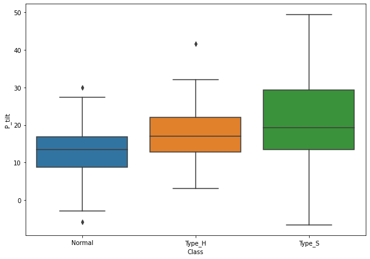

```python
plt.figure(figsize=(10,7))
sns.boxplot(x='Class', y='P_tilt', data= df)
plt.show()
```

type_s is largest class with p_tilt value.

mean is slightly higher of type_s.

there are some extreme values in normal and type_h class.

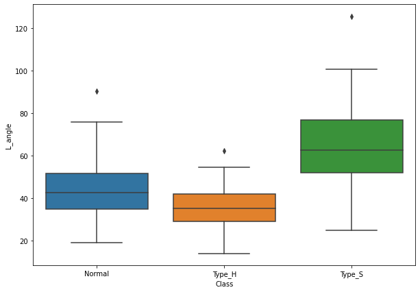

```python
plt.figure(figsize=(10,7))
sns.boxplot(x='Class', y='L_angle', data= df)
plt.show()
```

type_s is largest class with L_angle value.

each class has one outliers.

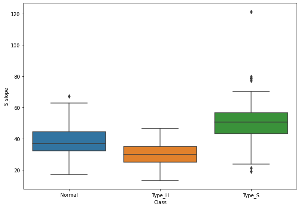

```python
plt.figure(figsize=(10,7))
sns.boxplot(x='Class', y='S_slope', data= df)
plt.show()
```

type_s is largest class with s_slope value.

there are some extreme values

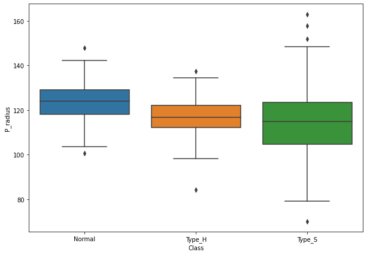

```python
plt.figure(figsize=(10,7))
sns.boxplot(x='Class', y='P_radius', data= df)
plt.show()
```

normal class is largest class with p_radius value.

there are outliers present.

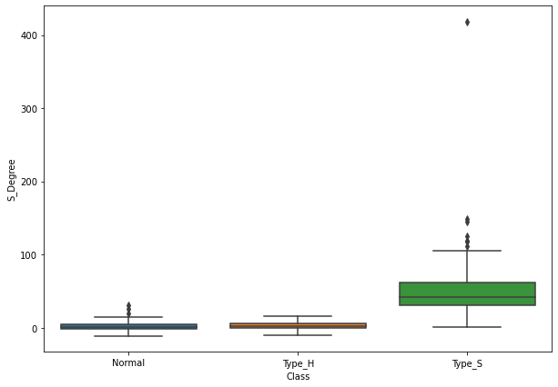

```python
plt.figure(figsize=(10,7))
sns.boxplot(x='Class', y='S_Degree', data= df)
plt.show()
```

type_s is largest class with S-degree value.

there are some extreme values in normal and type_s class.

**Split data into X and Y**

```python
le=LabelEncoder()
df['Class']=le.fit_transform(df['Class'])
df['Class'].value_counts()
```

```
2    150
0    100
1     60
Name: Class, dtype: int64
```

here 0 is normal class 1 is type_h and 2 is type_s class

```python
df['Class']=df['Class'].astype('category')
```

```python
df.dtypes
```

```
P_incidence     float64
P_tilt          float64
L_angle         float64
S_slope         float64
P_radius        float64
S_Degree        float64
Class          category
dtype: object
```

```python
X=df.drop(columns='Class')
X
```

|  | P_incidence | P_tilt | L_angle | S_slope | P_radius | S_Degree |
| --- | --- | --- | --- | --- | --- | --- |
| 0 | 38.505273 | 16.964297 | 35.112814 | 21.540976 | 127.632875 | 7.986683 |
| 1 | 54.920858 | 18.968430 | 51.601455 | 35.952428 | 125.846646 | 2.001642 |
| 2 | 44.362490 | 8.945435 | 46.902096 | 35.417055 | 129.220682 | 4.994195 |
| 3 | 48.318931 | 17.452121 | 48.000000 | 30.866809 | 128.980308 | -0.910941 |
| 4 | 45.701789 | 10.659859 | 42.577846 | 35.041929 | 130.178314 | -3.388910 |
| ... | ... | ... | ... | ... | ... | ... |
| 305 | 80.111572 | 33.942432 | 85.101608 | 46.169139 | 125.593624 | 100.292107 |
| 306 | 95.480229 | 46.550053 | 59.000000 | 48.930176 | 96.683903 | 77.283072 |
| 307 | 74.094731 | 18.823727 | 76.032156 | 55.271004 | 128.405731 | 73.388216 |
| 308 | 87.679087 | 20.365613 | 93.822416 | 67.313473 | 120.944829 | 76.730629 |
| 309 | 48.259920 | 16.417462 | 36.329137 | 31.842457 | 94.882336 | 28.343799 |

310 rows × 6 columns

```python
y=df["Class"]
y
```

```
0      0
1      0
2      0
3      0
4      0
      ..
305    2
306    2
307    2
308    2
309    2
Name: Class, Length: 310, dtype: category
Categories (3, int64): [0, 1, 2]
```

**Split data into train and test with 80:20 proportion**

```python
XScaled  = X.apply(zscore)  # convert all attributes to Z scale

XScaled.describe().T
```

|  | count | mean | std | min | 25% | 50% | 75% | max |
| --- | --- | --- | --- | --- | --- | --- | --- | --- |
| P_incidence | 310.0 | 1.042177e-16 | 1.001617 | -1.996010 | -0.817398 | -0.104925 | 0.719464 | 4.029206 |
| P_tilt | 310.0 | 2.096889e-16 | 1.001617 | -2.411664 | -0.688114 | -0.118606 | 0.458116 | 3.191402 |
| L_angle | 310.0 | 1.980495e-16 | 1.001617 | -2.047652 | -0.806027 | -0.127862 | 0.597549 | 3.984615 |
| S_slope | 310.0 | 2.829278e-17 | 1.001617 | -2.207741 | -0.716842 | -0.040960 | 0.726941 | 5.855771 |
| P_radius | 310.0 | -5.071212e-16 | 1.001617 | -3.597963 | -0.542383 | 0.026138 | 0.567621 | 3.395818 |
| S_Degree | 310.0 | -1.277204e-16 | 1.001617 | -0.996172 | -0.658507 | -0.387450 | 0.399768 | 10.460350 |

```python
X_train, X_test, y_train, y_test = train_test_split(X, y, test_size=0.2, random_state=10)
```

**Train a Supervised Learning Classification base model using KNN classifier.**

```python
KNN = KNeighborsClassifier(n_neighbors= 5 , metric = 'euclidean' ) #Building knn with 5 neighbors
```

```python
KNN.fit(X_train, y_train)
predicted_labels = KNN.predict(X_test)
predictedlabels = KNN.predict(X_train)
```

**Print all the possible performance metrics for both train and test data.**

```python
print('Accuracy on Training data:',KNN.score(X_train, y_train) )
print('Accuracy on Test data:',KNN.score(X_test, y_test) )
```

```
Accuracy on Training data: 0.9153225806451613
Accuracy on Test data: 0.7096774193548387
```

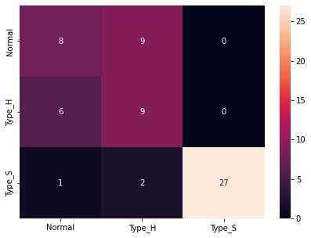

```python
cm = confusion_matrix(y_test, predicted_labels, labels=[0, 1,2])
df_cm = pd.DataFrame(cm, index = [i for i in ["Normal","Type_H","Type_S"]],
                  columns = [i for i in ["Normal","Type_H","Type_S"]])
plt.figure(figsize = (7,5))
sns.heatmap(df_cm, annot=True ,fmt='g')
plt.show()
```

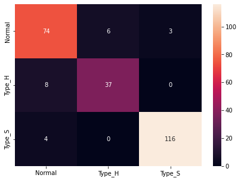

```python
cm = confusion_matrix(y_train, predictedlabels, labels=[0, 1,2])
df_cm = pd.DataFrame(cm, index = [i for i in ["Normal","Type_H","Type_S"]],
                  columns = [i for i in ["Normal","Type_H","Type_S"]])
plt.figure(figsize = (7,5))
sns.heatmap(df_cm, annot=True ,fmt='g')
plt.show()
```

```python
print("classification  Matrix:\n",classification_report(y_test,predicted_labels))
```

```
classification  Matrix:
               precision    recall  f1-score   support

           0       0.53      0.47      0.50        17
           1       0.45      0.60      0.51        15
           2       1.00      0.90      0.95        30

    accuracy                           0.71        62
   macro avg       0.66      0.66      0.65        62
weighted avg       0.74      0.71      0.72        62
```

```python
print("classification  Matrix:\n",classification_report(y_train,predictedlabels))
```

```
classification  Matrix:
               precision    recall  f1-score   support

           0       0.86      0.89      0.88        83
           1       0.86      0.82      0.84        45
           2       0.97      0.97      0.97       120

    accuracy                           0.92       248
   macro avg       0.90      0.89      0.90       248
weighted avg       0.92      0.92      0.92       248
```

here accuracy of train data is is 91.5% but accuracy of test data is 70.9% this is because overfitting of data

**Experiment with various parameters to improve performance of the base model**

```python
train_score=[]
test_score=[]
for k in range(1,51):
    KNN = KNeighborsClassifier(n_neighbors= k , metric = 'euclidean' )
    KNN.fit(X_train, y_train)
    train_score.append(KNN.score(X_train, y_train))
    test_score.append(KNN.score(X_test, y_test))
```

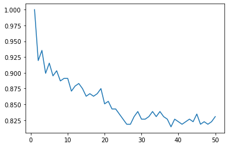

```python
plt.plot(range(1,51),train_score)
plt.show()
```

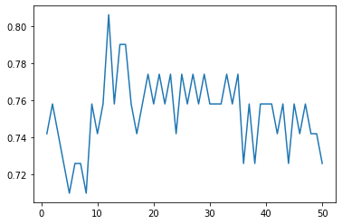

```python
plt.plot(range(1,51),test_score)
plt.show()
```

we can see that maximum accuracy on test data is when k is less than 20

```python
k=[1,3,5,7,9,11,13,15,17,19]
for i in k:
    KNN = KNeighborsClassifier(n_neighbors=i, metric = 'euclidean' )
    KNN.fit(X_train, y_train)
    predicted_labels = KNN.predict(X_test)
    print('Accuracy on Training data for k {} is {}:'.format(i,KNN.score(X_train, y_train)))
    print('Accuracy on Test data for k {} is {}:'.format(i,KNN.score(X_test, y_test)))
    print("classification  Matrix:\n",classification_report(y_test,predicted_labels))
```

```
Accuracy on Training data for k 1 is 1.0:
Accuracy on Test data for k 1 is 0.7419354838709677:
classification  Matrix:
               precision    recall  f1-score   support

           0       0.57      0.47      0.52        17
           1       0.53      0.67      0.59        15
           2       0.97      0.93      0.95        30

    accuracy                           0.74        62
   macro avg       0.69      0.69      0.68        62
weighted avg       0.75      0.74      0.74        62

Accuracy on Training data for k 3 is 0.9354838709677419:
Accuracy on Test data for k 3 is 0.7419354838709677:
classification  Matrix:
               precision    recall  f1-score   support

           0       0.57      0.47      0.52        17
           1       0.53      0.67      0.59        15
           2       0.97      0.93      0.95        30

    accuracy                           0.74        62
   macro avg       0.69      0.69      0.68        62
weighted avg       0.75      0.74      0.74        62

Accuracy on Training data for k 5 is 0.9153225806451613:
Accuracy on Test data for k 5 is 0.7096774193548387:
classification  Matrix:
               precision    recall  f1-score   support

           0       0.53      0.47      0.50        17
           1       0.45      0.60      0.51        15
           2       1.00      0.90      0.95        30

    accuracy                           0.71        62
   macro avg       0.66      0.66      0.65        62
weighted avg       0.74      0.71      0.72        62

Accuracy on Training data for k 7 is 0.9032258064516129:
```

[output cut: 74 more lines]

```
   macro avg       0.70      0.70      0.69        62
weighted avg       0.76      0.74      0.75        62

Accuracy on Training data for k 19 is 0.875:
Accuracy on Test data for k 19 is 0.7741935483870968:
classification  Matrix:
               precision    recall  f1-score   support

           0       0.58      0.65      0.61        17
           1       0.62      0.67      0.65        15
           2       1.00      0.90      0.95        30

    accuracy                           0.77        62
   macro avg       0.73      0.74      0.73        62
weighted avg       0.79      0.77      0.78        62
```

This KNN model gives best result when k = 15

*finding the best model fit for accurate results*

```python
LR_model=LogisticRegression()
KNN_model=KNeighborsClassifier(n_neighbors=15)
GN_model=GaussianNB()
GN_model=GaussianNB()
svc_model_linear = SVC(kernel='linear',C=1,gamma=.6)
svc_model_rbf = SVC(kernel='rbf',degree=2,C=.009)
svc_model_poly  = SVC(kernel='poly',degree=2,gamma=0.1,C=.01)
```

```python
seed = 7
# prepare models
models = []
models.append(('LR', LR_model))
models.append(('KNN', KNN_model))
models.append(('NB', GN_model))
models.append(('SVM-linear', svc_model_linear))
models.append(('SVM-poly', svc_model_poly))
models.append(('SVM-rbf', svc_model_rbf))
# evaluate each model in turn
results = []
names = []
scoring = 'accuracy'
for name, model in models:
    kfold = model_selection.KFold(n_splits=10, random_state=seed,shuffle=True)
    cv_results = model_selection.cross_val_score(model,XScaled,y, cv=kfold, scoring=scoring)
    results.append(cv_results)
    names.append(name)
    msg = "%s: %f (%f)" % (name, cv_results.mean(), cv_results.std())
    print(msg)
```

```
LR: 0.848387 (0.061290)
KNN: 0.790323 (0.058154)
NB: 0.825806 (0.035921)
SVM-linear: 0.851613 (0.070968)
SVM-poly: 0.483871 (0.070674)
SVM-rbf: 0.483871 (0.070674)
```

We can see that SVM-linear is giving the highest accuracy with std devation of 0.070

```python
svc_model_linear = SVC(kernel='linear',C=1,gamma=.6)
svc_model_linear.fit(X_train, y_train)
predicted_labels = svc_model_linear.predict(X_test)
print('Accuracy on Test data:',svc_model_linear.score(X_test, y_test) )
print("classification  Matrix:\n",classification_report(y_test,predicted_labels))
```

```
Accuracy on Test data: 0.8225806451612904
classification  Matrix:
               precision    recall  f1-score   support

           0       0.73      0.65      0.69        17
           1       0.63      0.80      0.71        15
           2       1.00      0.93      0.97        30

    accuracy                           0.82        62
   macro avg       0.79      0.79      0.79        62
weighted avg       0.84      0.82      0.83        62
```

**Clearly showcase improvement in performance achieved.**

After finding optimal K

A. Accuracy: +9% improvement

**Clearly state which parameters contributed most to improve model performance**

finding the optimal k helped imporving the accuracy of model

c and gamma values improved the model accuracy.

finding the right classification model will accuratly prdict the class of the disease

## Part B

A bank X is on a massive digital transformation for all its departments. Bank has a growing customer base whee majority of them are liability customers (depositors) vs borrowers (asset customers). The bank is interested in expanding the borrowers base rapidly to bring in more business via loan interests. A campaign that the bank ran in last quarter showed an average single digit conversion rate. Digital transformation being the core strength of the business strategy, marketing department wants to devise effective campaigns with better target marketing to increase the conversion ratio to double digit with same budget as per last campaign. "

**Read both the Datasets ‘Data1’ and ‘Data 2’ as DataFrame and store them into two separate variables.**

```python
df1= pd.read_csv("data1.csv")
df1
```

|  | ID | Age | CustomerSince | HighestSpend | ZipCode | HiddenScore | MonthlyAverageSpend | Level |
| --- | --- | --- | --- | --- | --- | --- | --- | --- |
| 0 | 1 | 25 | 1 | 49 | 91107 | 4 | 1.6 | 1 |
| 1 | 2 | 45 | 19 | 34 | 90089 | 3 | 1.5 | 1 |
| 2 | 3 | 39 | 15 | 11 | 94720 | 1 | 1.0 | 1 |
| 3 | 4 | 35 | 9 | 100 | 94112 | 1 | 2.7 | 2 |
| 4 | 5 | 35 | 8 | 45 | 91330 | 4 | 1.0 | 2 |
| ... | ... | ... | ... | ... | ... | ... | ... | ... |
| 4995 | 4996 | 29 | 3 | 40 | 92697 | 1 | 1.9 | 3 |
| 4996 | 4997 | 30 | 4 | 15 | 92037 | 4 | 0.4 | 1 |
| 4997 | 4998 | 63 | 39 | 24 | 93023 | 2 | 0.3 | 3 |
| 4998 | 4999 | 65 | 40 | 49 | 90034 | 3 | 0.5 | 2 |
| 4999 | 5000 | 28 | 4 | 83 | 92612 | 3 | 0.8 | 1 |

5000 rows × 8 columns

```python
df2= pd.read_csv("data2.csv")
df2
```

|  | ID | Mortgage | Security | FixedDepositAccount | InternetBanking | CreditCard | LoanOnCard |
| --- | --- | --- | --- | --- | --- | --- | --- |
| 0 | 1 | 0 | 1 | 0 | 0 | 0 | NaN |
| 1 | 2 | 0 | 1 | 0 | 0 | 0 | NaN |
| 2 | 3 | 0 | 0 | 0 | 0 | 0 | NaN |
| 3 | 4 | 0 | 0 | 0 | 0 | 0 | NaN |
| 4 | 5 | 0 | 0 | 0 | 0 | 1 | NaN |
| ... | ... | ... | ... | ... | ... | ... | ... |
| 4995 | 4996 | 0 | 0 | 0 | 1 | 0 | 0.0 |
| 4996 | 4997 | 85 | 0 | 0 | 1 | 0 | 0.0 |
| 4997 | 4998 | 0 | 0 | 0 | 0 | 0 | 0.0 |
| 4998 | 4999 | 0 | 0 | 0 | 1 | 0 | 0.0 |
| 4999 | 5000 | 0 | 0 | 0 | 1 | 1 | 0.0 |

5000 rows × 7 columns

**Print shape and Column Names and DataTypes of both the Dataframes.**

```python
df1.shape
```

```
(5000, 8)
```

```python
df1.columns
```

```
Index(['ID', 'Age', 'CustomerSince', 'HighestSpend', 'ZipCode', 'HiddenScore',
       'MonthlyAverageSpend', 'Level'],
      dtype='object')
```

```python
df1.dtypes
```

```
ID                       int64
Age                      int64
CustomerSince            int64
HighestSpend             int64
ZipCode                  int64
HiddenScore              int64
MonthlyAverageSpend    float64
Level                    int64
dtype: object
```

```python
df2.shape
```

```
(5000, 7)
```

```python
df2.columns
```

```
Index(['ID', 'Mortgage', 'Security', 'FixedDepositAccount', 'InternetBanking',
       'CreditCard', 'LoanOnCard'],
      dtype='object')
```

```python
df2.dtypes
```

```
ID                       int64
Mortgage                 int64
Security                 int64
FixedDepositAccount      int64
InternetBanking          int64
CreditCard               int64
LoanOnCard             float64
dtype: object
```

Merge both the Dataframes on ‘ID’ feature to form a single DataFrame

```python
df=pd.merge(df1, df2, on='ID')
df.reset_index(inplace=True)
```

```python
df=df.drop(['index'], axis = 1)
```

```python
df.shape
```

```
(5000, 14)
```

```python
df
```

|  | ID | Age | CustomerSince | HighestSpend | ZipCode | HiddenScore | MonthlyAverageSpend | Level | Mortgage | Security | FixedDepositAccount | InternetBanking | CreditCard | LoanOnCard |
| --- | --- | --- | --- | --- | --- | --- | --- | --- | --- | --- | --- | --- | --- | --- |
| 0 | 1 | 25 | 1 | 49 | 91107 | 4 | 1.6 | 1 | 0 | 1 | 0 | 0 | 0 | NaN |
| 1 | 2 | 45 | 19 | 34 | 90089 | 3 | 1.5 | 1 | 0 | 1 | 0 | 0 | 0 | NaN |
| 2 | 3 | 39 | 15 | 11 | 94720 | 1 | 1.0 | 1 | 0 | 0 | 0 | 0 | 0 | NaN |
| 3 | 4 | 35 | 9 | 100 | 94112 | 1 | 2.7 | 2 | 0 | 0 | 0 | 0 | 0 | NaN |
| 4 | 5 | 35 | 8 | 45 | 91330 | 4 | 1.0 | 2 | 0 | 0 | 0 | 0 | 1 | NaN |
| ... | ... | ... | ... | ... | ... | ... | ... | ... | ... | ... | ... | ... | ... | ... |
| 4995 | 4996 | 29 | 3 | 40 | 92697 | 1 | 1.9 | 3 | 0 | 0 | 0 | 1 | 0 | 0.0 |
| 4996 | 4997 | 30 | 4 | 15 | 92037 | 4 | 0.4 | 1 | 85 | 0 | 0 | 1 | 0 | 0.0 |
| 4997 | 4998 | 63 | 39 | 24 | 93023 | 2 | 0.3 | 3 | 0 | 0 | 0 | 0 | 0 | 0.0 |
| 4998 | 4999 | 65 | 40 | 49 | 90034 | 3 | 0.5 | 2 | 0 | 0 | 0 | 1 | 0 | 0.0 |
| 4999 | 5000 | 28 | 4 | 83 | 92612 | 3 | 0.8 | 1 | 0 | 0 | 0 | 1 | 1 | 0.0 |

5000 rows × 14 columns

**Change Datatype of below features to ‘Object' ‘CreditCard’, ‘InternetBanking’, ‘FixedDepositAccount’, ‘Security’, ‘Level’, ‘HiddenScore’**

```python
df.dtypes
```

```
ID                       int64
Age                      int64
CustomerSince            int64
HighestSpend             int64
ZipCode                  int64
HiddenScore              int64
MonthlyAverageSpend    float64
Level                    int64
Mortgage                 int64
Security                 int64
FixedDepositAccount      int64
InternetBanking          int64
CreditCard               int64
LoanOnCard             float64
dtype: object
```

```python
df = df.astype({"CreditCard": object, "InternetBanking": object, "FixedDepositAccount": object, "Security": object,  "Level": object,  "HiddenScore": object})
```

```python
df.info()
```

```
<class 'pandas.core.frame.DataFrame'>
RangeIndex: 5000 entries, 0 to 4999
Data columns (total 14 columns):
 #   Column               Non-Null Count  Dtype
---  ------               --------------  -----
 0   ID                   5000 non-null   int64
 1   Age                  5000 non-null   int64
 2   CustomerSince        5000 non-null   int64
 3   HighestSpend         5000 non-null   int64
 4   ZipCode              5000 non-null   int64
 5   HiddenScore          5000 non-null   object
 6   MonthlyAverageSpend  5000 non-null   float64
 7   Level                5000 non-null   object
 8   Mortgage             5000 non-null   int64
 9   Security             5000 non-null   object
 10  FixedDepositAccount  5000 non-null   object
 11  InternetBanking      5000 non-null   object
 12  CreditCard           5000 non-null   object
 13  LoanOnCard           4980 non-null   float64
dtypes: float64(2), int64(6), object(6)
memory usage: 547.0+ KB
```

**Visualize distribution of Target variable ‘LoanOnCard’ and clearly share insights.**

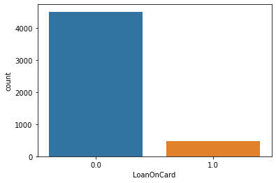

```python
sns.countplot(x ='LoanOnCard', data = df)
plt.show()
```

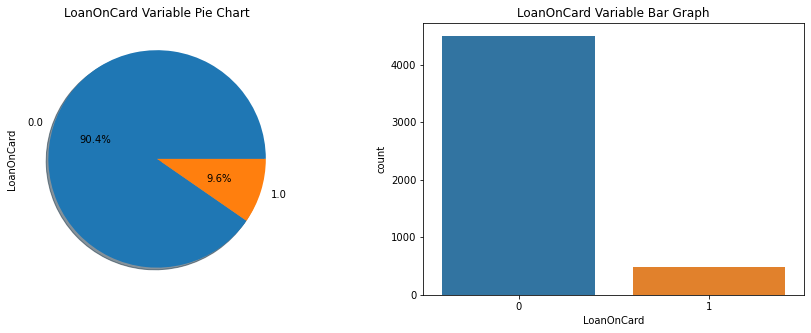

```python
f,axes=plt.subplots(1,2,figsize=(15,5))
df['LoanOnCard'].value_counts().plot.pie(autopct='%1.1f%%',ax=axes[0],shadow=True)
sns.countplot('LoanOnCard',data=df,ax=axes[1],order=[0,1])
axes[0].set_title('LoanOnCard Variable Pie Chart')
axes[1].set_title('LoanOnCard Variable Bar Graph')
plt.show()
```

we can see that 90.4% of people does not have loan on credit card

**Check the percentage of missing values and impute if required.**

```python
df.isnull().sum()
```

```
ID                      0
Age                     0
CustomerSince           0
HighestSpend            0
ZipCode                 0
HiddenScore             0
MonthlyAverageSpend     0
Level                   0
Mortgage                0
Security                0
FixedDepositAccount     0
InternetBanking         0
CreditCard              0
LoanOnCard             20
dtype: int64
```

```python
df=df.dropna()
```

```python
df.isnull().sum()
```

```
ID                     0
Age                    0
CustomerSince          0
HighestSpend           0
ZipCode                0
HiddenScore            0
MonthlyAverageSpend    0
Level                  0
Mortgage               0
Security               0
FixedDepositAccount    0
InternetBanking        0
CreditCard             0
LoanOnCard             0
dtype: int64
```

**Check for unexpected values in each categorical variable and impute with best suitable value**

```python
col=['CreditCard', 'InternetBanking', 'FixedDepositAccount', 'Security', 'Level', 'HiddenScore','LoanOnCard']
for i in col:
    print(df[i].value_counts())
```

```
0    3514
1    1466
Name: CreditCard, dtype: int64
1    2974
0    2006
Name: InternetBanking, dtype: int64
0    4678
1     302
Name: FixedDepositAccount, dtype: int64
0    4460
1     520
Name: Security, dtype: int64
1    2089
3    1496
2    1395
Name: Level, dtype: int64
1    1466
2    1293
4    1215
3    1006
Name: HiddenScore, dtype: int64
0.0    4500
1.0     480
Name: LoanOnCard, dtype: int64
```

looks like there are no unexpected values in categorical variables

**Split data into X and Y.**

droping columns id and zipcode as they do not contribute in descion making

```python
df=df.drop(['ID','ZipCode'], axis = 1)
```

```python
X=df.drop(columns='LoanOnCard')
y=df['LoanOnCard'] #target variable
```

**Split data into train and test. Keep 25% data reserved for testing**

```python
X_train, X_test, y_train, y_test = train_test_split(X, y, test_size=0.25, random_state=10)
```

**Train a Supervised Learning Classification base model - Logistic Regression.**

```python
logit = LogisticRegression()
logit.fit(X_train, y_train)
logit_pred = logit.predict(X_test)

print('Accuracy on Training data:',logit.score(X_train, y_train) )
print('Accuracy on Test data:',logit.score(X_test, y_test) )
```

```
Accuracy on Training data: 0.9461847389558233
Accuracy on Test data: 0.9590361445783132
```

accuracy on training data is 94% and on testing data is 95%.

balance between accuracy of training and testing data is good.

**Print evaluation metrics for the model and clearly share insights.**

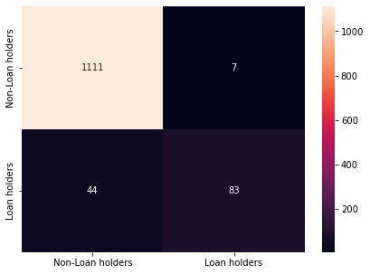

```python
cm = confusion_matrix(y_test, logit_pred, labels=[0, 1])
df_cm = pd.DataFrame(cm, index = [i for i in ["Non-Loan holders","Loan holders"]],
                  columns = [i for i in ["Non-Loan holders","Loan holders"]])
plt.figure(figsize = (7,5))
sns.heatmap(df_cm, annot=True ,fmt='g')
plt.show()
```

```python
print("classification  Matrix:\n",classification_report(y_test,logit_pred))
```

```
classification  Matrix:
               precision    recall  f1-score   support

         0.0       0.96      0.99      0.98      1118
         1.0       0.92      0.65      0.76       127

    accuracy                           0.96      1245
   macro avg       0.94      0.82      0.87      1245
weighted avg       0.96      0.96      0.96      1245
```

we are getting very less error.

presion on class 1 is less compare to class 0.

recall suggestes that we do not have enough samples of class 1

**Balance the data using the right balancing technique.**

We will do the sampling and check how recall values improves in this case.

```python
smote_nc=SMOTENC(categorical_features=[1,3,5],random_state=42) #specifying categorical column numbers
x_s,y_s=smote_nc.fit_resample(X,y)
```

```python
print('Before sampling:')
print(y.value_counts())
```

```
Before sampling:
0.0    4500
1.0     480
Name: LoanOnCard, dtype: int64
```

```python
print('After sampling:')
print(y_s.value_counts())
```

```
After sampling:
1.0    4500
0.0    4500
Name: LoanOnCard, dtype: int64
```

**Again train the same previous model on balanced data.**

```python
Xs_train, Xs_test, ys_train, ys_test = train_test_split(x_s, y_s, test_size=0.25, random_state=10)
```

```python
logit = LogisticRegression()
logit.fit(Xs_train, ys_train)
logit_pred = logit.predict(Xs_test)
print('Accuracy on Training data:',logit.score(Xs_train, ys_train) )
print('Accuracy on Test data:',logit.score(Xs_test, ys_test) )
```

```
Accuracy on Training data: 0.8911111111111111
Accuracy on Test data: 0.9017777777777778
```

**print evaluation metrics and clearly share differences observed.**

lets see the confusion matrix

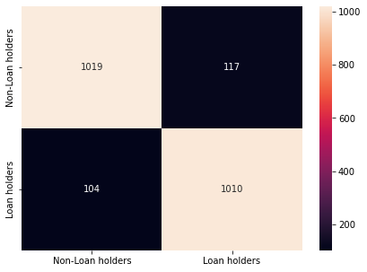

```python
cm = confusion_matrix(ys_test, logit_pred, labels=[0, 1])
df_cm = pd.DataFrame(cm, index = [i for i in ["Non-Loan holders","Loan holders"]],
                  columns = [i for i in ["Non-Loan holders","Loan holders"]])
plt.figure(figsize = (7,5))
sns.heatmap(df_cm, annot=True ,fmt='g')
plt.show()
```

```python
print("classification  Matrix:\n",classification_report(ys_test,logit_pred))
```

```
classification  Matrix:
               precision    recall  f1-score   support

         0.0       0.91      0.90      0.90      1136
         1.0       0.90      0.91      0.90      1114

    accuracy                           0.90      2250
   macro avg       0.90      0.90      0.90      2250
weighted avg       0.90      0.90      0.90      2250
```

we can see that recall value is increased after sampling the data.

so after countering the imbalance in data with sampling we find a optimal model.

**Train a base model each for SVM, KNN.**

```python
KNN_model=KNeighborsClassifier(n_neighbors=5)
KNN.fit(X_train, y_train)
predicted_labels = KNN.predict(X_test)
print('Accuracy on Training data:',KNN.score(X_train, y_train) )
print('Accuracy on Test data:',KNN.score(X_test, y_test) )
```

```
Accuracy on Training data: 0.9151271753681393
Accuracy on Test data: 0.9116465863453815
```

```python
svc=SVC()
svc.fit(X_train, y_train)
predicted_labels = svc.predict(X_test)
print('Accuracy on Training data:',svc.score(X_train, y_train) )
print('Accuracy on Test data:',svc.score(X_test, y_test) )
```

```
Accuracy on Training data: 0.9113788487282464
Accuracy on Test data: 0.9036144578313253
```

**Tune parameters for each of the models wherever required and finalize a model**

Without doing any sampling using k-fold we are getiing good accuracy score in logistic regresssion.

performing stratified k fold for finding best parameters and model.

```python
models = []
models.append(('LR', LR_model))
models.append(('KNN', KNN_model))
models.append(('SVM', svc))

# evaluate each model in turn
results = []
names = []
scoring = 'accuracy'
for name, model in models:
    kfold = model_selection.StratifiedKFold(n_splits=10)
    cv_results = model_selection.cross_val_score(model,  X,y, cv=kfold, scoring=scoring)
    results.append(cv_results)
    names.append(name)
    msg = "%s: %f (%f)" % (name, cv_results.mean(), cv_results.std())
    print(msg)
```

```
LR: 0.949398 (0.008122)
KNN: 0.913855 (0.006504)
SVM: 0.908835 (0.003935)
```

selecting final model logistic regression as it performs well in training and testing test.

model performed well in k-fold cross validation as well.

Deviation is very low.

```python
from sklearn.model_selection import GridSearchCV
grid={"C":np.logspace(-3,3,7), "penalty":["l1","l2"]}# l1 lasso l2 ridge
logreg=LogisticRegression()
logreg_cv=GridSearchCV(logreg,grid,cv=10)
logreg_cv.fit(X_train,y_train)

print("tuned hpyerparameters :(best parameters) ",logreg_cv.best_params_)
print("accuracy :",logreg_cv.best_score_)
```

```
tuned hpyerparameters :(best parameters)  {'C': 1.0, 'penalty': 'l2'}
accuracy : 0.946186434603088
```

```python
logit = LogisticRegression(C=1.0,penalty='l2')
logit.fit(X_train, y_train)
logit_pred = logit.predict(X_test)
print('Accuracy on Training data:',logit.score(X_train, y_train) )
print('Accuracy on Test data:',logit.score(X_test, y_test) )
```

```
Accuracy on Training data: 0.9461847389558233
Accuracy on Test data: 0.9590361445783132
```

**Print evaluation metrics for final model**

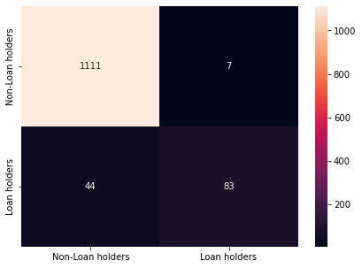

```python
cm = confusion_matrix(y_test, logit_pred, labels=[0, 1])
df_cm = pd.DataFrame(cm, index = [i for i in ["Non-Loan holders","Loan holders"]],
                  columns = [i for i in ["Non-Loan holders","Loan holders"]])
plt.figure(figsize = (7,5))
sns.heatmap(df_cm, annot=True ,fmt='g')
plt.show()
```

```python
print("classification  Matrix:\n",classification_report(y_test,logit_pred))
```

```
classification  Matrix:
               precision    recall  f1-score   support

         0.0       0.96      0.99      0.98      1118
         1.0       0.92      0.65      0.76       127

    accuracy                           0.96      1245
   macro avg       0.94      0.82      0.87      1245
weighted avg       0.96      0.96      0.96      1245
```

**Share improvement achieved from base model to final model.**

precision values for both class are above 90%.

good accuracy after stratified Kfold.